# Midterm_final

Jasmine Siyu Wu, Zoe Yoo

10/18/2021

```r
url <- "https://logos-world.net/wp-content/uploads/2020/11/Zillow-Logo.png"
```

[figure not shown]

# Zillow Model Update: Boulder County, CO

## Introduction

Through user feedback and data analysis, Zillow has found that their current predictions for homes in Boulder County, CO are unusually inaccurate compared to other areas and states. Compared to more traditional cities, Boulder and its surrounding area have unique characteristics; this contributes to a weaker relationship between selected variables used for countrywide analysis and housing prices. As such, our group has been tasked with incorporating additional cultural and physical factors of Boulder County into the model to increase its accuracy and reliability.

Though this model is centered around Boulder County, its enhancement is applicable to many other areas. Boulder, and Boulder County by extension, has a close proximity to many natural areas, in addition to a fairly new urban framework and low median age of existing buildings. These characteristics are similar to many, more recently established Western cities than those on the East Coast. Boulder County is still very dominantly white, with the Census estimating in 2019 that 77.4% of the county is white (non-Hispanic); it is also not densely populated, particularly in comparison to urban counties. Being a peri-urban center outside of Denver, Boulder is a useful area to improve our model for because many U.S. cities have similar ‘exterior’ cities of which property values have been understudied in the past, but are essential to the wider urban framework.

```r
knitr::opts_chunk$set(echo = TRUE,fig.width = 10, fig.height = 5)

library(tidyverse)
library(sf)
library(spdep)
library(caret)
library(ckanr)
library(FNN)
library(grid)
library(gridExtra)
library(ggcorrplot)
library(kableExtra)
library(jtools)     # for regression model plots
library(ggstance)
library(osmdata)
library(knitr)
library(tidycensus)
library(scales)
library(stargazer)
library(kableExtra)

options(scipen=999)
options(tigris_class = "sf")
options(tigris_use_cache = TRUE)

# functions and data directory
root.dir = "https://raw.githubusercontent.com/urbanSpatial/Public-Policy-Analytics-Landing/master/DATA/"
source("https://raw.githubusercontent.com/urbanSpatial/Public-Policy-Analytics-Landing/master/functions.r")


mapTheme <- function(base_size = 12) {
  theme(
    text = element_text( color = "black"),
    plot.title = element_text(size = 16,colour = "black"),
    plot.subtitle=element_text(face="italic"),
    plot.caption=element_text(hjust=0),
    axis.ticks = element_blank(),
    panel.background = element_blank(),axis.title = element_blank(),
    axis.text = element_blank(),
    axis.title.x = element_blank(),
    axis.title.y = element_blank(),
    panel.grid.minor = element_blank(),
    panel.border = element_rect(colour = "black", fill=NA, size=2),
    strip.text.x = element_text(size = 14))
}

plotTheme <- function(base_size = 12) {
  theme(
    text = element_text( color = "black"),
    plot.title = element_text(size = 16,colour = "black"),
    plot.subtitle = element_text(face="italic"),
    plot.caption = element_text(hjust=0),
    axis.ticks = element_blank(),
    panel.background = element_blank(),
    panel.grid.major = element_line("grey80", size = 0.1),
    panel.grid.minor = element_blank(),
    panel.border = element_rect(colour = "black", fill=NA, size=2),
    strip.background = element_rect(fill = "grey80", color = "white"),
    strip.text = element_text(size=12),
    axis.title = element_text(size=12),
    axis.text = element_text(size=10),
    plot.background = element_blank(),
    legend.background = element_blank(),
    legend.title = element_text(colour = "black", face = "italic"),
    legend.text = element_text(colour = "black", face = "italic"),
    strip.text.x = element_text(size = 14)
  )
}

qBr <- function(df, variable, rnd) {
 if (missing(rnd)) {
    as.character(quantile(round(df[[variable]],0),
                 c(.01,.2,.4,.6,.8), na.rm=T))
 } else if (rnd == FALSE | rnd == F) {
    as.character(formatC(quantile(df[[variable]],
                 c(.01,.2,.4,.6,.8), na.rm=T), digits = 3))
 }
}

q5 <- function(variable) {as.factor(ntile(variable, 5))}
palette5 <- c("#eff3ff", "#bdd7e7", "#6baed6", "#3182bd", "#08519c")
```

## Data Exploration

### Gathering Data

The home price data our group used for training the model was released in 2021 by the Boulder County Assessor’s Office. The Boulder County Assessor’s Office distributes data relating to buildings, land, and permits, among others, but our base dataset was that of home sales between 2019-2021. As can be seen in the map below, home prices are clearly not random, but tied to local geography.

```r
# attach demographic and socioeconomic data to house points
boulder.sf <-
  st_join(boulder.sf,
          dplyr::select(tractsBC19, GEOID, MedRent, TotalPop, pctWhite, pctBachelors, pctPoverty, popDensity, raceContext, incomeContext))

boulder.sf <-
  st_join(boulder.sf, tracts.sf) %>%
  mutate(boulder.sf, stop.Buffer=lengths(st_intersects(st_buffer(boulder.sf, 804), bus_stops.sf))) %>%
  mutate(boulder.sf,
         playground.Buffer=lengths(st_intersects(st_buffer(boulder.sf, 1609/2), playgrounds.sf))) %>%
  mutate(boulder.sf,
         school.Buffer=lengths(st_intersects(st_buffer(boulder.sf, 1609/2), schools.sf))) %>%
  mutate(boulder.sf,
         parks.Buffer=lengths(st_intersects(st_buffer(boulder.sf, 1609/2), parks.sf))) %>%
  mutate(boulder.sf,
         highway.Buffer=lengths(st_intersects(st_buffer(boulder.sf, 1609/2), highways.sf)))

boulder.sf <-
  st_join(boulder.sf, places)

# average nearest neighbor distance to 1-NN and 3-NN parks
st_c <- st_coordinates #st_c(coordinates)

boulder.sf <-
  boulder.sf %>%
    mutate(park_nn1 = nn_function(st_c(boulder.sf), st_c(st_centroid(parks.sf)), 1)/1609,
           park_nn3 = nn_function(st_c(boulder.sf), st_c(st_centroid(parks.sf)), 3)/1609) #in mile

# average nearest neighbor distance to 1-NN and 3-NN schools
boulder.sf <-
  boulder.sf %>%
    mutate(school_nn1 = nn_function(st_c(boulder.sf), st_c(schools.sf), 1)/1609,
           school_nn3 = nn_function(st_c(boulder.sf), st_c(schools.sf), 3)/1609) # in mile

# average nearest neighbor distance to 1-NN and 3-NN playgrounds
boulder.sf <-
  boulder.sf %>%
    mutate(playground_nn1 = nn_function(st_c(boulder.sf), st_c(playgrounds.sf), 1)/1609,
           playground_nn3 = nn_function(st_c(boulder.sf), st_c(playgrounds.sf), 3)/1609) # in mile

# average nearest neighbor distance to 1-NN and 3-NN lakes
boulder.sf <-
  boulder.sf %>%
    mutate(lake_nn1 = nn_function(st_c(boulder.sf), st_c(st_centroid(lakes.sf)), 1)/1609,
           lake_nn3 = nn_function(st_c(boulder.sf), st_c(st_centroid(lakes.sf)), 3)/1609) # in mile
```

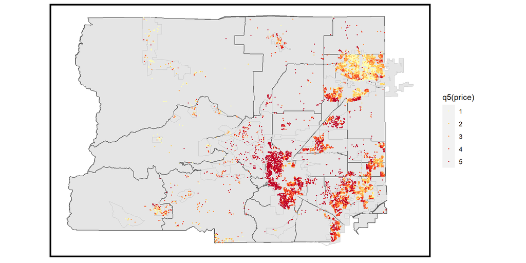

```r
# visualize raw data
ggplot() +
  geom_sf(data=county_boundary, color="white")+
  geom_sf(data=tracts.sf, alpha=.4)+
  geom_sf(data=bc.places, show.legend = NA, color='grey', lwd=0.1)+
  geom_sf(data = boulder.sf, aes(color = q5(price)),
          show.legend = "point", size = 0.3)+
  scale_color_brewer(type=seq, palette = "YlOrRd")+
  mapTheme()
```

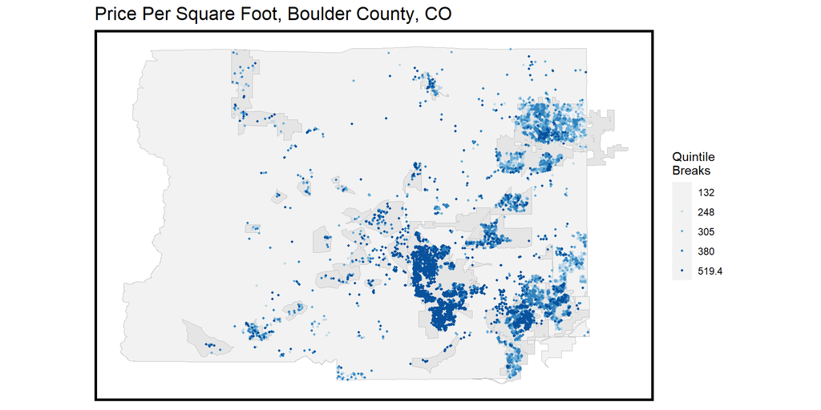

```r
ggplot() +
  geom_sf(data=county_boundary, show.legend = NA, color='grey',alpha=0.5, lwd=0.3)+
  geom_sf(data=bc.places, show.legend = NA, color='grey', lwd=0.1)+
  geom_sf(data = boulder.sf, aes(colour = q5(PricePerSF)),
          show.legend = "point", size = 0.8) +
  scale_colour_manual(values = palette5,
                   labels=qBr(boulder.sf,"PricePerSF"),
                   name="Quintile\nBreaks") +
  labs(title="Price Per Square Foot, Boulder County, CO") +
  mapTheme()
```

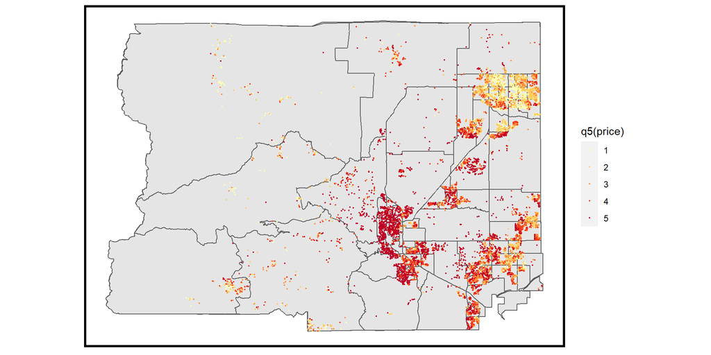

```r
#map 1:
ggplot() +
  geom_sf(data=county_boundary, color="white")+
  geom_sf(data=tracts.sf, alpha=.4)+
  geom_sf(data = boulder.sf, aes(color = q5(price)),
          show.legend = "point", size = 0.3)+
  scale_color_brewer(type=seq, palette = "YlOrRd")+
  mapTheme()
```

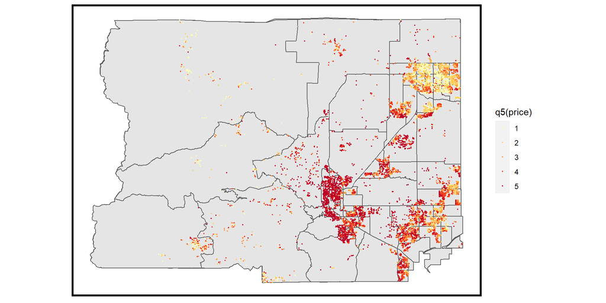

```r
#map 2:
ggplot() +
  geom_sf(data=county_boundary, color="white")+
  geom_sf(data=tracts.sf, alpha=.4)+
  geom_sf(data = boulder.sf, aes(color = q5(price)),
          show.legend = "point", size = 0.3)+
  scale_color_brewer(type=seq, palette = "YlOrRd")+
  mapTheme()
```

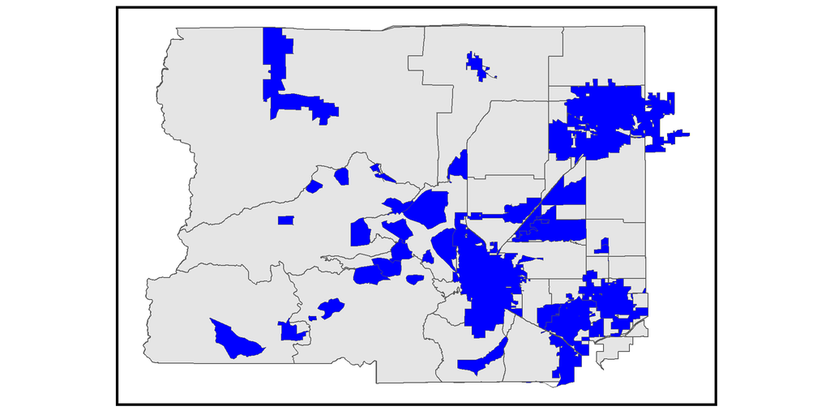

```r
#map 3:
ggplot() +
  geom_sf(data=county_boundary)+
  geom_sf(data=tracts.sf, alpha=.4)+
  geom_sf(data=bc.places, show.legend = NA, fill='blue', lwd=0.1)+
  mapTheme()
```

### Finding Correlation

```r
boulder.sf %>%
  st_drop_geometry() %>%
  select(price, builtYear, bsmtSF, carStorageSF, nbrBedRoom, nbrRoomsNobath,
         mainfloorSF, nbrThreeQtrBaths, nbrFullBaths, nbrHalfBaths,
         TotalFinishedSF, Age, PricePerSF) %>%
  summary() %>%
  kable(align='c', caption="Numeric Internal Characteristics",
        digits=2, col.names = c("Price",
                                "Year Built",
                                "Basement SqFt",
                                "Car Storage SqFt",
                                "# Bedrooms",
                                "# Rooms (Not Including Bathrooms)",
                                "Main Floor SqFt",
                                "# 3/4 Bathrooms",
                                "# Full Bathrooms",
                                "# 1/2 Bathrooms",
                                "Total Finished SqFt",
                                "Age",
                                "Price per SqFt")) %>%
  kable_styling()
```

Numeric Internal Characteristics

|  | Price | Year Built | Basement SqFt | Car Storage SqFt | # Bedrooms | # Rooms (Not Including Bathrooms) | Main Floor SqFt | # 3/4 Bathrooms | # Full Bathrooms | # 1/2 Bathrooms | Total Finished SqFt | Age | Price per SqFt |
| --- | --- | --- | --- | --- | --- | --- | --- | --- | --- | --- | --- | --- | --- |
|  | Min. : 10000 | Min. :1860 | Min. : 0.0 | Min. : 0.0 | Min. : 0.000 | Min. : 0.00 | Min. : 0.0 | Min. :0.0000 | Min. : 0.000 | Min. :0.000 | Min. : 0 | Min. : 0.00 | Min. : 8.333 |
|  | 1st Qu.: 452650 | 1st Qu.:1972 | 1st Qu.: 135.5 | 1st Qu.: 380.0 | 1st Qu.: 3.000 | 1st Qu.: 6.00 | 1st Qu.: 922.8 | 1st Qu.:0.0000 | 1st Qu.: 1.000 | 1st Qu.:0.000 | 1st Qu.: 1276 | 1st Qu.: 15.00 | 1st Qu.:261.387 |
|  | Median : 605700 | Median :1992 | Median : 699.0 | Median : 462.0 | Median : 3.000 | Median : 7.00 | Median :1203.5 | Median :0.0000 | Median : 2.000 | Median :1.000 | Median : 1792 | Median : 29.00 | Median :339.160 |
|  | Mean : 746344 | Mean :1987 | Mean : 744.1 | Mean : 471.6 | Mean : 3.444 | Mean : 7.39 | Mean :1313.1 | Mean :0.6167 | Mean : 1.781 | Mean :0.555 | Mean : 1955 | Mean : 33.83 | Mean : Inf |
|  | 3rd Qu.: 831260 | 3rd Qu.:2006 | 3rd Qu.:1126.0 | 3rd Qu.: 600.0 | 3rd Qu.: 4.000 | 3rd Qu.: 9.00 | 3rd Qu.:1619.0 | 3rd Qu.:1.0000 | 3rd Qu.: 2.000 | 3rd Qu.:1.000 | 3rd Qu.: 2443 | 3rd Qu.: 49.00 | 3rd Qu.:474.153 |
|  | Max. :7350000 | Max. :2021 | Max. :4534.0 | Max. :3040.0 | Max. :24.000 | Max. :28.00 | Max. :7795.0 | Max. :9.0000 | Max. :12.000 | Max. :3.000 | Max. :10188 | Max. :161.00 | Max. : Inf |

```r
boulder.sf %>%
  st_drop_geometry() %>%
  select(price, designCodeDscr, qualityCodeDscr, bldgClassDscr,
         ConstCodeDscr, carStorageTypeDscr, AcDscr, HeatingDscr,
         bsmtTypeDscr, ExtWallDscrPrim, IntWallDscr, Roof_CoverDscr) %>%
  head() %>%
  kable(align='c', caption="Categorical Internal Characteristics",
        col.names = c("Price", "Design Code",
                      "Quality Code",
                      "Building Class",
                      "Construction Code",
                      "Car Storage",
                      "Air Conditioning Type",
                      "Heating Type",
                      "Basement Type",
                      "Exterior Wall Material",
                      "Internal Wall Material",
                      "Roof Material")) %>%
  kable_styling()
```

Categorical Internal Characteristics

| Price | Design Code | Quality Code | Building Class | Construction Code | Car Storage | Air Conditioning Type | Heating Type | Basement Type | Exterior Wall Material | Internal Wall Material | Roof Material |
| --- | --- | --- | --- | --- | --- | --- | --- | --- | --- | --- | --- |
| 540000 | 1 Story - Ranch | AVERAGE | SINGLE FAM RES IMPROVEMENTS | Frame | ATTACHED GARAGE AREA |  | Hot Water | WALK-OUT BASEMENT FINISHED AREA | Frame Wood/Shake | Hardwood Panel |  |
| 420000 | 1 Story - Ranch | AVERAGE | SINGLE FAM RES IMPROVEMENTS | Frame | ATTACHED GARAGE AREA | Whole House | Forced Air | SUBTERRANEAN BASEMENT FINISHED AREA | Frame Wood/Shake | Drywall | Asphalt |
| 475000 | Bi-level | AVERAGE | SINGLE FAM RES IMPROVEMENTS | Frame | ATTACHED GARAGE AREA | Whole House | Forced Air | LOWER LVL GARDEN FINISHED (BI-SPLIT LVL) | Frame Wood/Shake | Drywall | Asphalt |
| 455000 | Split-level | AVERAGE + | SINGLE FAM RES IMPROVEMENTS | Frame | ATTACHED GARAGE AREA | Whole House | Forced Air | LOWER LVL GARDEN FINISHED (BI-SPLIT LVL) | Frame Wood/Shake | Drywall | Asphalt |
| 518000 | 2-3 Story | GOOD ++ | SINGLE FAM RES IMPROVEMENTS | Frame | 0 |  | Forced Air | 0 | Frame Wood/Shake | Drywall |  |
| 851500 | 2-3 Story | GOOD ++ | SINGLE FAM RES IMPROVEMENTS | Frame | ATTACHED GARAGE AREA | Whole House | Forced Air | SUBTERRANEAN BASEMENT FINISHED AREA | Frame Wood/Shake | Drywall | Asphalt |

```r
boulder.sf %>%
  st_drop_geometry() %>%
  select(price, highway.Buffer, stop.Buffer, park_nn1, park_nn3, parks.Buffer, school_nn1, school_nn3,
         school.Buffer, playground_nn1, playground_nn3, playground.Buffer,
         lake_nn1, lake_nn3) %>%
  summary() %>%
  kable(align='c', caption="External Characteristics/Amenities",
        digits=2, col.names = c("Price", "Bus Stop (1/2 mile Buffer",
                      "Highways (1/2 mile Buffer",
                      "Parks (First Nearest Neighbor)",
                      "Parks (Three Nearest Neighbors)",
                      "Parks (1/2 mile Buffer)",
                      "Schools (First Nearest Neighbor)",
                      "Schools (Three Nearest Neighbors)",
                      "Schools (1/2 mile Buffer)",
                      "Playgrounds (First Nearest Neighbor)",
                      "Playgrounds (Three Nearest Neighbors)",
                      "Playgrounds (1/2 mile Buffer)",
                      "Lakes (First Nearest Neighbor)",
                      "Lakes (Three Nearest Neighbors)")) %>%
  kable_styling()
```

External Characteristics/Amenities

[output not shown]

```r
boulder.sf %>%
  st_drop_geometry() %>%
  select(price, NAMELSAD, NAME.y) %>%
  head() %>%
  kable(align='c', caption="Spatial Structure",
        col.names = c("Price", "Census Tract", "Municipality")) %>%
  kable_styling()
```

Spatial Structure

| Price | Census Tract | Municipality |
| --- | --- | --- |
| 540000 | Census Tract 137.06 | NA |
| 420000 | Census Tract 133.06 | Longmont city, Colorado |
| 475000 | Census Tract 129.05 | Lafayette city, Colorado |
| 455000 | Census Tract 129.07 | Lafayette city, Colorado |
| 518000 | Census Tract 137.06 | NA |
| 851500 | Census Tract 132.15 | Longmont city, Colorado |

Above, we have included several summary tables of the variables we considered, separated by type. Numeric internal characteristics and categorical are separated to describe them more accurately. The categorical internal characteristics are not summarized, but merely show the first few entries to give an idea of what the categories include; for example, under heating, we can see that there is variation between hot water and forced air. External characteristics include both “nearest neighbor” calculations of the average distance (in miles) from each home and the nearest specified number of amenities, and “buffer” calculations of how many amenities are within a half-mile radius. Lastly included is a simple table of examples of the spatial contexts available for use; census tracts are more akin to neighborhoods, while municipalities (NA values are unincorporated areas) give a more general idea of price clustering.

The problem with looking at all variables at once is that of multicollinearity, or the presence of variables that are highly related; a good example of this is number of bedrooms and number of rooms overall, which are both closely tied to home price but also correlated with each other. Thus, we did not use all of the shown above for our predictive model, but had to decide which were the most applicable; among other tools, we used a correlation matrix (shown below) to quickly see where there might be correlation between numeric variables.

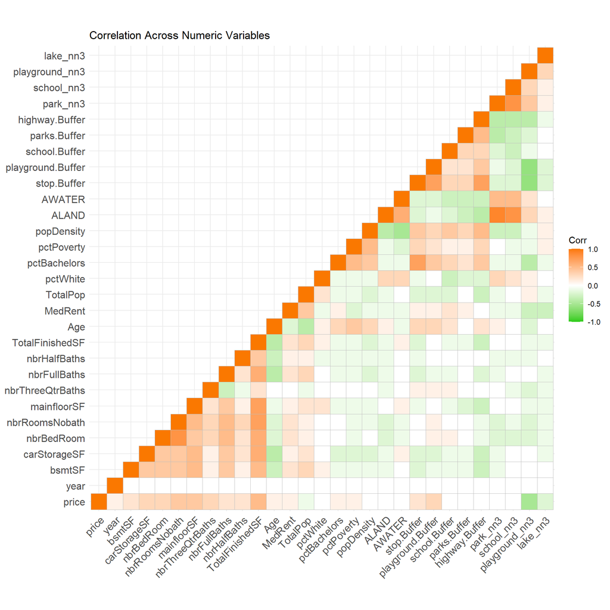

```r
numericVars <-
  select_if(st_drop_geometry(boulder.sf), is.numeric) %>%
  dplyr::select(-MUSA_ID, -toPredict, -builtYear, -Stories, -UnitCount, -PricePerSF, -B01001_001E, -B01001_001M,
                -playground_nn1, -park_nn1, -school_nn1, -lake_nn1, -bld_num, -section_num, -EffectiveYear,
                -CompCode) %>%
  na.omit()

# only for continuous variables
ggcorrplot(  #correlation plot
  round(cor(numericVars), 1),
  p.mat = cor_pmat(numericVars),
  show.diag = TRUE,
  colors = c("#25CB10", "white", "#FA7800"),
  type="lower",
  insig = "blank") +
    labs(title = "Correlation Across Numeric Variables")
```

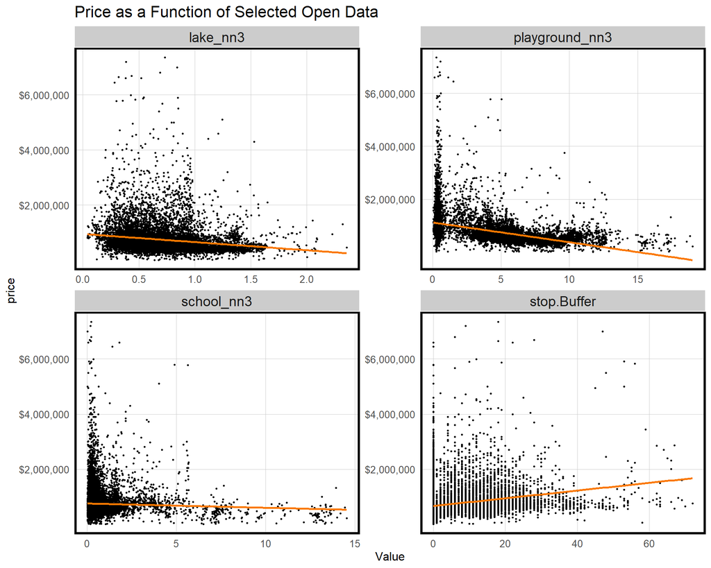

```r
st_drop_geometry(boulder.sf) %>%
  dplyr::select(price, school_nn3, lake_nn3, playground_nn3, stop.Buffer) %>%
  #filter(SalePrice <= 1000000, Age < 500) %>%
  gather(Variable, Value, -price) %>%
   ggplot(aes(Value, price)) + # the x and y axes are 3 variables and sale price
   scale_y_continuous(breaks=c(2000000,4000000,6000000), labels=c("$2,000,000","$4,000,000","$6,000,000"))+
     geom_point(size = .5) +
     geom_smooth(method = "lm", se=F, colour = "#FA7800") + # geom_smooth is the best fit line (method is linear regression)
     facet_wrap(~Variable, ncol = 2, scales = "free") +
     labs(title = "Price as a Function of Selected Open Data") +
     plotTheme()
```

## Model Methodology

Our method of prediction is through Linear Regression, or Ordinary Least Squares (OLS) Regression. This method takes in several different variables that we choose and creates a linear model based on these components; this is also termed as a ‘hedonic model.’ The ultimate premise of the hedonic model is to identify which characteristics, both internal characteristics such as square footage and age and external characteristics such as nearby amenities, are the best predictors (have the greatest effect) on overall home prices. “Least Squares” refers to the slope of the line, which is calculated by minimizing the squared difference between the prediction and observed prices.

Linear regression can be done with just one variable, which we have shown below in the case of `TotalFinishedSF`, or total finished square footage. The main values we considered are residual standard error, R<sup>2</sup>, and p-value. Residual standard is the error of the coefficient, which helps us understand how reliable the coefficient is. The p-value tells us whether the variable is a useful predictor, and R<sup>2</sup> is a percentage ‘goodness of fit’ indicator. Here, since the model of `TotalFinishedSF` has an R<sup>2</sup> of 0.248, about 24.8% of home price variation can be explained by `TotalFinishedSF`. By incorporating more variables into our model, we can better explain home price variation.

```r
areaReg <- lm(price ~ TotalFinishedSF, data = boulder.sf)

stargazer(areaReg, type="text")
```

```
##
## ================================================
##                         Dependent variable:
##                     ----------------------------
##                                price
## ------------------------------------------------
## TotalFinishedSF              303.609***
##                               (4.985)
##
## Constant                   152,932.600***
##                             (10,709.500)
##
## ------------------------------------------------
## Observations                   11,264
## R2                             0.248
## Adjusted R2                    0.248
## Residual Std. Error   471,726.600 (df = 11262)
## F Statistic         3,709.138*** (df = 1; 11262)
## ================================================
## Note:                *p<0.1; **p<0.05; ***p<0.01
```

## Model Results

```r
# can play with categorical variables?
reg1 <- lm(price ~ ., data = st_drop_geometry(boulder.sf) %>%
                             dplyr::select(price, Age, qualityCode, ConstCode, bsmtType, #designCode,
                                    carStorageSF, nbrBedRoom, TotalFinishedSF, mainfloorSF, Roof_Cover, #nbrRoomsNobath,
                                    nbrFullBaths, parks.Buffer, #playground.Buffer, school.Buffer,
                                    school_nn3, playground_nn1, lake_nn3, #park_nn3,
                                    popDensity, pctBachelors))
```

For testing the regression model, we broke the price data into a 75%/25% split, where we selected 75% of the data and used it to predict the values of the other 25%. The table for this “training” set is below:

```r
inTrain <- createDataPartition(
  y = paste(boulder.sf$Roof_Cover,
            boulder.sf$qualityCode, boulder.sf$Ac),
  p = .75, list = FALSE) %>%
  append(which(boulder.sf$qualityCode == "10")) %>%
  append(which(boulder.sf$GEOID == "08013012300")) %>%
  append(which(boulder.sf$ConstCode == "410"))

boulder.training <- boulder.sf[inTrain,]
boulder.test <- boulder.sf[-inTrain,]

reg.training <-
  lm(price ~ ., data = as.data.frame(boulder.training) %>%
       dplyr::select(price, Age, qualityCode, ConstCode, bsmtType, #designCode,
                     carStorageSF, nbrBedRoom, TotalFinishedSF, mainfloorSF, #nbrRoomsNobath,
                     nbrFullBaths, parks.Buffer, #playground.Buffer, school.Buffer,
                     school_nn3, playground_nn1, lake_nn3, #park_nn3,
                     popDensity, pctBachelors))

boulder.test <-
  boulder.test %>%
  mutate(Regression = "Baseline Regression",
         price.Predict = predict(reg.training, boulder.test),
         price.Error = price.Predict - price,
         price.AbsError = abs(price.Predict - price),
         price.APE = (abs(price.Predict - price))/price.Predict)

table <- reg.training %>%
  stargazer(type="html", median=TRUE, title="Results", align=TRUE)
```

```
##
## <table style="text-align:center"><caption><strong>Results</strong></caption>
## <tr><td colspan="2" style="border-bottom: 1px solid black"></td></tr><tr><td style="text-align:left"></td><td><em>Dependent variable:</em></td></tr>
## <tr><td></td><td colspan="1" style="border-bottom: 1px solid black"></td></tr>
## <tr><td style="text-align:left"></td><td>price</td></tr>
## <tr><td colspan="2" style="border-bottom: 1px solid black"></td></tr><tr><td style="text-align:left">Age</td><td>3,173.561<sup>***</sup></td></tr>
## <tr><td style="text-align:left"></td><td>(189.636)</td></tr>
## <tr><td style="text-align:left"></td><td></td></tr>
## <tr><td style="text-align:left">qualityCode20</td><td>120,619.400<sup>*</sup></td></tr>
## <tr><td style="text-align:left"></td><td>(67,237.070)</td></tr>
## <tr><td style="text-align:left"></td><td></td></tr>
## <tr><td style="text-align:left">qualityCode30</td><td>203,422.600<sup>***</sup></td></tr>
## <tr><td style="text-align:left"></td><td>(59,061.860)</td></tr>
## <tr><td style="text-align:left"></td><td></td></tr>
## <tr><td style="text-align:left">qualityCode31</td><td>211,547.300<sup>***</sup></td></tr>
## <tr><td style="text-align:left"></td><td>(60,721.090)</td></tr>
## <tr><td style="text-align:left"></td><td></td></tr>
## <tr><td style="text-align:left">qualityCode32</td><td>274,135.500<sup>***</sup></td></tr>
## <tr><td style="text-align:left"></td><td>(60,903.710)</td></tr>
## <tr><td style="text-align:left"></td><td></td></tr>
## <tr><td style="text-align:left">qualityCode40</td><td>328,518.500<sup>***</sup></td></tr>
## <tr><td style="text-align:left"></td><td>(60,309.340)</td></tr>
## <tr><td style="text-align:left"></td><td></td></tr>
## <tr><td style="text-align:left">qualityCode41</td><td>359,753.600<sup>***</sup></td></tr>
## <tr><td style="text-align:left"></td><td>(62,327.140)</td></tr>
## <tr><td style="text-align:left"></td><td></td></tr>
## <tr><td style="text-align:left">qualityCode42</td><td>485,036.200<sup>***</sup></td></tr>
## <tr><td style="text-align:left"></td><td>(61,790.900)</td></tr>
## <tr><td style="text-align:left"></td><td></td></tr>
## <tr><td style="text-align:left">qualityCode50</td><td>582,524.100<sup>***</sup></td></tr>
## <tr><td style="text-align:left"></td><td>(62,724.140)</td></tr>
## <tr><td style="text-align:left"></td><td></td></tr>
## <tr><td style="text-align:left">qualityCode51</td><td>942,213.500<sup>***</sup></td></tr>
## <tr><td style="text-align:left"></td><td>(68,373.190)</td></tr>
## <tr><td style="text-align:left"></td><td></td></tr>
## <tr><td style="text-align:left">qualityCode52</td><td>1,008,558.000<sup>***</sup></td></tr>
## <tr><td style="text-align:left"></td><td>(65,853.000)</td></tr>
## <tr><td style="text-align:left"></td><td></td></tr>
## <tr><td style="text-align:left">qualityCode60</td><td>1,544,815.000<sup>***</sup></td></tr>
## <tr><td style="text-align:left"></td><td>(71,076.440)</td></tr>
```

[output cut: 95 more lines]

```
## <tr><td style="text-align:left"></td><td>(1.934)</td></tr>
## <tr><td style="text-align:left"></td><td></td></tr>
## <tr><td style="text-align:left">pctBachelors</td><td>-1,033,108.000<sup>***</sup></td></tr>
## <tr><td style="text-align:left"></td><td>(268,487.100)</td></tr>
## <tr><td style="text-align:left"></td><td></td></tr>
## <tr><td style="text-align:left">Constant</td><td>366,176.900<sup>***</sup></td></tr>
## <tr><td style="text-align:left"></td><td>(91,311.290)</td></tr>
## <tr><td style="text-align:left"></td><td></td></tr>
## <tr><td colspan="2" style="border-bottom: 1px solid black"></td></tr><tr><td style="text-align:left">Observations</td><td>8,548</td></tr>
## <tr><td style="text-align:left">R<sup>2</sup></td><td>0.626</td></tr>
## <tr><td style="text-align:left">Adjusted R<sup>2</sup></td><td>0.624</td></tr>
## <tr><td style="text-align:left">Residual Std. Error</td><td>338,290.800 (df = 8502)</td></tr>
## <tr><td style="text-align:left">F Statistic</td><td>316.609<sup>***</sup> (df = 45; 8502)</td></tr>
## <tr><td colspan="2" style="border-bottom: 1px solid black"></td></tr><tr><td style="text-align:left"><em>Note:</em></td><td style="text-align:right"><sup>*</sup>p<0.1; <sup>**</sup>p<0.05; <sup>***</sup>p<0.01</td></tr>
## </table>
```

This table is a summary of the results from the training regression model; it is set up exactly the same way as the single variable model, just with more variables incorporated. Adding variables increased the R<sup>2</sup> for this model up to the level where it is able to explain 62% of actual price values.

**Cross Validation**

```r
fitControl <- trainControl(method = "cv", number = 100)
set.seed(825)

boulder_toPdt <- subset(boulder.sf, boulder.sf$toPredict==1)
boulder_pdt <- subset(boulder.sf, boulder.sf$toPredict==0)

reg1.cv <-
  train(price ~ ., data = st_drop_geometry(boulder_pdt) %>%
                                dplyr::select(price,Age, qualityCode, ConstCode, bsmtType, #designCode,
                                    carStorageSF, nbrBedRoom, TotalFinishedSF, mainfloorSF, Roof_Cover, #nbrRoomsNobath,
                                    nbrFullBaths, parks.Buffer, #playground.Buffer, school.Buffer,
                                    school_nn3, playground_nn1, lake_nn3, #park_nn3,
                                    popDensity, pctBachelors),
     method = "lm", trControl = fitControl, na.action = na.pass)

reg1.cv
```

```
## Linear Regression
##
## 11264 samples
##    16 predictor
##
## No pre-processing
## Resampling: Cross-Validated (100 fold)
## Summary of sample sizes: 11151, 11150, 11152, 11152, 11152, 11152, ...
## Resampling results:
##
##   RMSE      Rsquared   MAE
##   343536.4  0.6389513  198919.1
##
## Tuning parameter 'intercept' was held constant at a value of TRUE
```

```r
coords <- st_coordinates(boulder.sf)
neighborList <- knn2nb(knearneigh(coords, 5))
spatialWeights <- nb2listw(neighborList, style="W")
boulder.sf <- mutate(boulder.sf, lagPrice=lag.listw(spatialWeights, boulder.sf$price, zero.policy=TRUE, NAOK = TRUE))

coords.test <-  st_coordinates(boulder.test)
neighborList.test <- knn2nb(knearneigh(coords.test, 5))
spatialWeights.test <- nb2listw(neighborList.test, style="W")
boulder.test <-
  mutate(boulder.test,
         lagPrice = lag.listw(spatialWeights.test, boulder.test$price, zero.policy=TRUE, NAOK = TRUE),
         lagPriceError = lag.listw(spatialWeights.test, boulder.test$price.Error, zero.policy=TRUE, NAOK = TRUE))
```

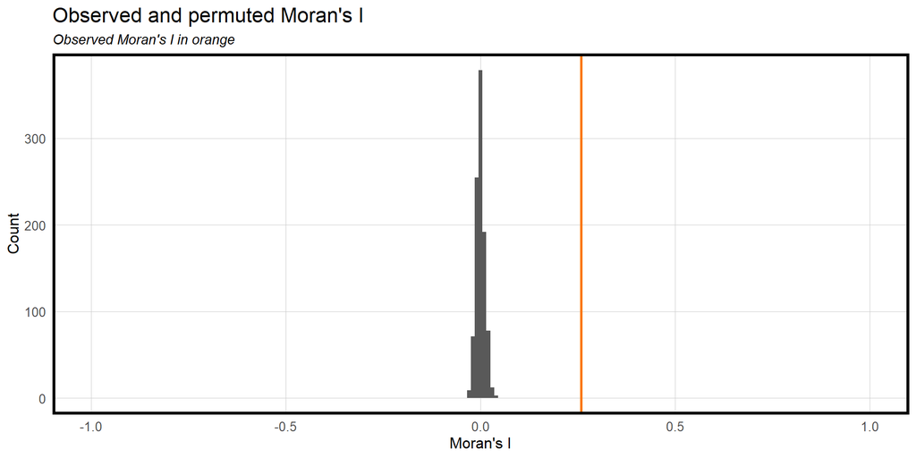

```r
moranTest <- moran.mc(boulder.test$price.Error,
                      spatialWeights.test, nsim = 999)

ggplot(as.data.frame(moranTest$res[c(1:999)]), aes(moranTest$res[c(1:999)])) +
  geom_histogram(binwidth = 0.01) +
  geom_vline(aes(xintercept = moranTest$statistic), colour = "#FA7800",size=1) +
  scale_x_continuous(limits = c(-1, 1)) +
  labs(title="Observed and permuted Moran's I",
       subtitle= "Observed Moran's I in orange",
       x="Moran's I",
       y="Count") +
  plotTheme()
```

```r
# no neighbohood so that usually using census tract
# https://www.bouldercounty.org/families/disease/covid-19-information/covid-19-vaccine-information/vaccine-data/
left_join(
  st_drop_geometry(boulder.test) %>%
    group_by(GEOID.x) %>%
    summarize(meanPrice = mean(price, na.rm = T)),
    mutate(boulder.test, predict.fe =
           predict(lm(price ~ GEOID.x, data = boulder.test),
                   boulder.test)) %>%
    st_drop_geometry %>%
    group_by(GEOID.x) %>%
    summarize(meanPrediction = mean(predict.fe))) %>%
    kable() %>% kable_styling()
```

| GEOID.x | meanPrice | meanPrediction |
| --- | --- | --- |
| 08013012101 | 1972941.9 | 1972941.9 |
| 08013012102 | 1347514.3 | 1347514.3 |
| 08013012103 | 1257184.0 | 1257184.0 |
| 08013012104 | 1649100.0 | 1649100.0 |
| 08013012105 | 1213565.0 | 1213565.0 |
| 08013012201 | 2114635.3 | 2114635.3 |
| 08013012202 | 949600.0 | 949600.0 |
| 08013012203 | 559770.4 | 559770.4 |
| 08013012204 | 1100000.0 | 1100000.0 |
| 08013012401 | 1238687.5 | 1238687.5 |
| 08013012501 | 758341.7 | 758341.7 |
| 08013012505 | 1291153.1 | 1291153.1 |
| 08013012507 | 708976.9 | 708976.9 |
| 08013012508 | 750800.0 | 750800.0 |
| 08013012509 | 959360.0 | 959360.0 |
| 08013012510 | 1584577.8 | 1584577.8 |
| 08013012511 | 810791.7 | 810791.7 |
| 08013012603 | 971079.3 | 971079.3 |
| 08013012605 | 715000.0 | 715000.0 |
| 08013012607 | 723428.6 | 723428.6 |
| 08013012608 | 641746.7 | 641746.7 |
| 08013012701 | 1228225.3 | 1228225.3 |
| 08013012705 | 755433.3 | 755433.3 |
| 08013012707 | 1707106.7 | 1707106.7 |
| 08013012708 | 821845.1 | 821845.1 |
| 08013012709 | 646480.0 | 646480.0 |
| 08013012710 | 1198148.0 | 1198148.0 |
| 08013012800 | 661797.1 | 661797.1 |
| 08013012903 | 762214.8 | 762214.8 |
| 08013012904 | 596248.5 | 596248.5 |
| 08013012905 | 580088.2 | 580088.2 |
| 08013012907 | 617574.4 | 617574.4 |
| 08013013003 | 802639.1 | 802639.1 |
| 08013013004 | 762503.0 | 762503.0 |
| 08013013005 | 710835.0 | 710835.0 |
| 08013013006 | 799252.7 | 799252.7 |
| 08013013201 | 941809.1 | 941809.1 |
| 08013013202 | 955833.3 | 955833.3 |
| 08013013205 | 1052858.3 | 1052858.3 |
| 08013013207 | 522929.6 | 522929.6 |
| 08013013208 | 474065.1 | 474065.1 |
| 08013013210 | 387592.3 | 387592.3 |
| 08013013211 | 572632.9 | 572632.9 |
| 08013013212 | 475287.5 | 475287.5 |
| 08013013213 | 696147.4 | 696147.4 |
| 08013013302 | 504984.1 | 504984.1 |
| 08013013305 | 384449.0 | 384449.0 |
| 08013013306 | 387984.2 | 387984.2 |
| 08013013307 | 421278.8 | 421278.8 |
| 08013013308 | 409216.4 | 409216.4 |
| 08013013401 | 396219.0 | 396219.0 |
| 08013013402 | 434834.8 | 434834.8 |
| 08013013503 | 440184.4 | 440184.4 |
| 08013013505 | 384616.7 | 384616.7 |
| 08013013506 | 476581.2 | 476581.2 |
| 08013013507 | 401511.1 | 401511.1 |
| 08013013508 | 489566.1 | 489566.1 |
| 08013013601 | 815413.9 | 815413.9 |
| 08013013602 | 440087.0 | 440087.0 |
| 08013013701 | 929569.3 | 929569.3 |
| 08013013702 | 607981.2 | 607981.2 |
| 08013060600 | 677195.0 | 677195.0 |
| 08013060700 | 797778.8 | 797778.8 |
| 08013060800 | 484717.5 | 484717.5 |
| 08013060900 | 639583.3 | 639583.3 |
| 08013061300 | 777586.4 | 777586.4 |
| 08013061400 | 783000.0 | 783000.0 |

```r
reg.nhood <- lm(price ~ ., data = as.data.frame(boulder.training) %>%
                  dplyr::select(GEOID.x, price, Age, qualityCode,
                     carStorageSF, nbrBedRoom, TotalFinishedSF,
                     park_nn3, school_nn3, playground_nn3, lake_nn3,
                     popDensity, pctWhite, pctBachelors))

summary(reg.training)
```

[output not shown]

```r
boulder.test.nhood <-
  boulder.test %>%
  mutate(Regression = "Neighborhood Effects",
         price.Predict = predict(reg.nhood, boulder.test),
         price.Error = price.Predict- price,
         price.AbsError = abs(price.Predict- price),
         price.APE = (abs(price.Predict- price)) / price)
```

```r
bothRegressions <-
  rbind(
    dplyr::select(boulder.test, starts_with("price"), Regression, GEOID.x) %>%
      mutate(lagPriceError = lag.listw(spatialWeights.test, price.Error)),
    dplyr::select(boulder.test.nhood, starts_with("price"), Regression, GEOID.x) %>%
      mutate(lagPriceError = lag.listw(spatialWeights.test, price.Error)))

st_drop_geometry(bothRegressions) %>%
  gather(Variable, Value, -Regression, -GEOID.x) %>%
  filter(Variable == "price.AbsError" | Variable == "price.APE") %>%
  group_by(Regression, Variable) %>%
    summarize(meanValue = mean(Value, na.rm = T)) %>%
    spread(Variable, meanValue) %>%
    kable() %>%
    kable_styling()
```

| Regression | price.AbsError | price.APE |
| --- | --- | --- |
| Baseline Regression | 184133.7 | 0.2863357 |
| Neighborhood Effects | 150092.5 | 0.2208174 |

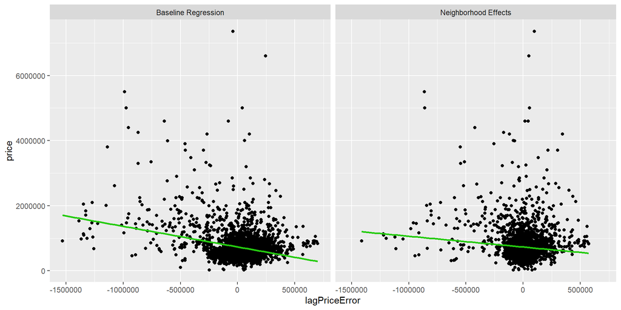

```r
ggplot(data=bothRegressions)+
  geom_point(aes(lagPriceError, price))+
  stat_smooth(aes(lagPriceError, price),
              method = "lm", se = FALSE, size = 1, colour="#25CB10") +
  facet_wrap(~Regression)
```

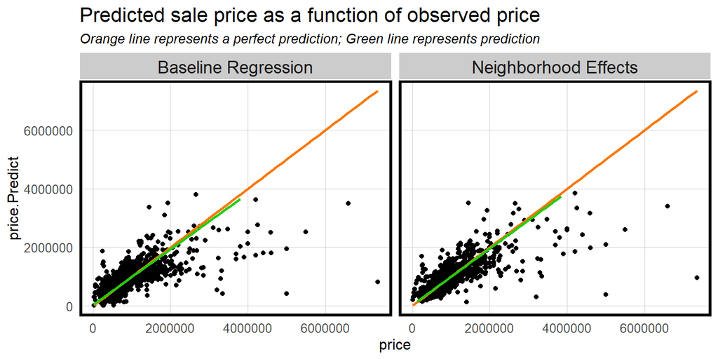

```r
bothRegressions %>%
  dplyr::select(price.Predict, price, Regression) %>%
    ggplot(aes(price, price.Predict)) +
  geom_point() +
  stat_smooth(aes(price, price),
             method = "lm", se = FALSE, size = 1, colour="#FA7800") +
  stat_smooth(aes(price.Predict, price),
              method = "lm", se = FALSE, size = 1, colour="#25CB10") +
  facet_wrap(~Regression) +
  labs(title="Predicted sale price as a function of observed price",
       subtitle="Orange line represents a perfect prediction; Green line represents prediction") +
  plotTheme()
```

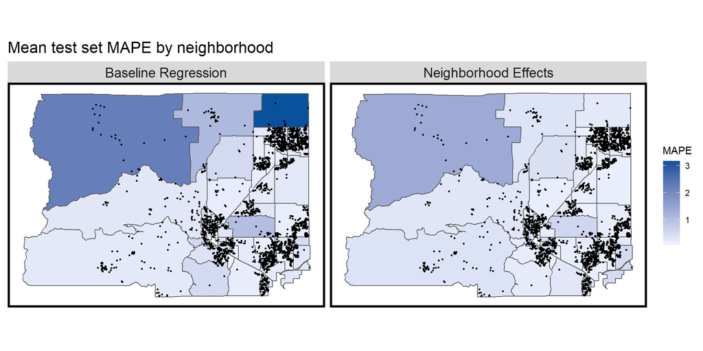

```r
st_drop_geometry(bothRegressions) %>%
  group_by(Regression, GEOID.x) %>%
  summarize(mean.MAPE = mean(price.APE, na.rm = T)) %>%
  ungroup() %>%
  left_join(tractsBC19, by = c("GEOID.x" = "GEOID")) %>%
    st_sf() %>%
    ggplot() +
      geom_sf(aes(fill = mean.MAPE)) +
      geom_sf(data = bothRegressions, colour = "black", size = .5) +
      facet_wrap(~Regression) +
      scale_fill_gradient(low = palette5[1], high = palette5[5],
                          name = "MAPE") +
      labs(title = "Mean test set MAPE by neighborhood") +
      mapTheme()
```

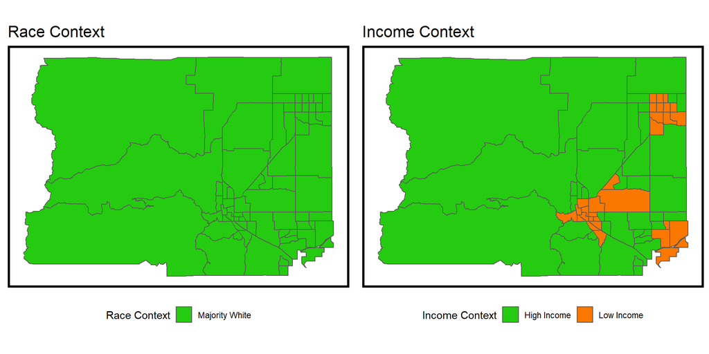

```r
grid.arrange(ncol = 2,
  ggplot() + geom_sf(data = na.omit(tractsBC19), aes(fill = raceContext)) +
    scale_fill_manual(values = c("#25CB10", "#FA7800"), name="Race Context") +
    labs(title = "Race Context") +
    mapTheme() + theme(legend.position="bottom"),
  ggplot() + geom_sf(data = na.omit(tractsBC19), aes(fill = incomeContext)) +
    scale_fill_manual(values = c("#25CB10", "#FA7800"), name="Income Context") +
    labs(title = "Income Context") +
    mapTheme() + theme(legend.position="bottom"))
```

```r
st_join(bothRegressions, tractsBC19) %>%
  filter(!is.na(incomeContext)) %>%
  group_by(Regression, incomeContext) %>%
  summarize(mean.MAPE = scales::percent(mean(price.APE, na.rm = T))) %>%
  st_drop_geometry() %>%
  spread(incomeContext, mean.MAPE) %>%
  kable(caption = "Test set MAPE by neighborhood income context") %>%
  kable_styling()
```

Test set MAPE by neighborhood income context

| Regression | High Income | Low Income |
| --- | --- | --- |
| Baseline Regression | 30% | 25% |
| Neighborhood Effects | 22% | 22% |